# Basic diet data analyses with R

Sarah Gaichas

7/1/2021

## Read in the newer data

The original diet dataset is called `allwt2.csv` and the updated dataset is called `allwt2_fis.csv`. I have downloaded both from the google drive and put both in a folder called `data`.

Brian showed a way to read directly from google drive with the code below. This is useful if the file is updated. It may send you to an authentication screen when you run it. My console said:

> The googledrive package is requesting access to your Google account. Select a pre-authorised account or enter ‘0’ to obtain a new token. Press Esc/Ctrl + C to abort.

I pressed 1 for my stored account, which was the only choice. It only does this once per session.

Either way, once the file is on your local machine, the same code reads it in. It is easy to read data in to R, but the hard part is usually having R know where to look for the data. I can tell R where to look for it on my computer in order to read it in, or I can read it directly from the google drive.

### Loading packages and reading data into R

In the first lines below, I tell R to use the package called `googledrive` that can download the files directly. The second line tells R to use `here` which establishes the place on my computer where I am running my session as the place to put the downloaded files. The next three lines use `googledrive` functions to find all files of the type comma separated values (.csv) and download the two files that we want. Comments not read by R start with #.

```r
library(googledrive) #load the library that can work with googledrive
library(here) #load the library that knows where my R project is on my computer

drive_find(type='csv') #this finds a list of 652 files for me!

# format is ("filenameongdrive", "where I want it to go", should I write over the local file if it is already there?

drive_download("allwt2.csv", here('data/allwt2.csv'), overwrite = T)

drive_download("allwt2_fis.csv", here('data/allwt2_fis.csv'), overwrite = T)
```

The code below reads the files into R objects using the R command `read.csv` on the two files now located in the `data` folder. R is making two objects that we can do further analysis on–`dietdat1` (the original dataset) and `dietdat2` (the newer dataaset with different prey categories).

I use the assignment operator, an arrow `<-`, to show that the named object on the left hand side comes from the function or set of commands on the right hand side. This will get used a lot! A shortcut in Rstudio for the arrow is to hold the `option` (or `alt`) key at the same time as the `-` key. You can also just type `<` and `-` together. (You can also use an equals sign `=` for assignment, but this can get confusing when you need an `=` to use a function elsewhere in the code.)

```r
dietdat1 <- read.csv(here('data/allwt2.csv'), sep = ',', h=T, na.strings = c(NA)) #read in first dataset

dietdat2 <- read.csv(here("data/allwt2_fis.csv")) #read in second dataset (I've left off the defaults above)
```

If we type `dietdat2` at the prompt, we see the some or all of the data object, depending on how long it is.

```r
dietdat2
```

```
##         X svspp epu season year nstom   meanlen     varlen numlen minlen maxlen
## 1       1    13  GB   FALL 1973    NA        NA         NA     NA     NA     NA
## 2       2    13  GB   FALL 1974    NA        NA         NA     NA     NA     NA
## 3       3    13  GB   FALL 1975    NA        NA         NA     NA     NA     NA
## 4       4    13  GB   FALL 1976    NA        NA         NA     NA     NA     NA
## 5       5    13  GB   FALL 1977    NA        NA         NA     NA     NA     NA
## 6       6    13  GB   FALL 1978     5  88.40000  60.800000      5     80    101
## 7       7    13  GB   FALL 1978     5  88.40000  60.800000      5     80    101
## 8       8    13  GB   FALL 1978     5  88.40000  60.800000      5     80    101
## 9       9    13  GB   FALL 1978     5  88.40000  60.800000      5     80    101
## 10     10    13  GB   FALL 1978     5  88.40000  60.800000      5     80    101
## 11     11    13  GB   FALL 1978     5  88.40000  60.800000      5     80    101
## 12     12    13  GB   FALL 1978     5  88.40000  60.800000      5     80    101
## 13     13    13  GB   FALL 1978     5  88.40000  60.800000      5     80    101
## 14     14    13  GB   FALL 1978     5  88.40000  60.800000      5     80    101
```

[output cut: 13322 more lines]

### Quick views of the data

Quick ways to view the data are the R functions `head`, which gives the top 6 lines of the dataset including the column names, and `names`, which just tells you the column (variable) names. For R functions that operate on an object, you just put the object’s name inside the () immediately following the function name. Note there is no space between function name and the opening (!.

```r
head(dietdat1) #show top 6 rows and all columns
```

```
##   X svspp epu season year nstom meanlen varlen numlen minlen maxlen minstom
## 1 1    13  GB   FALL 1973    NA      NA     NA     NA     NA     NA      NA
## 2 2    13  GB   FALL 1974    NA      NA     NA     NA     NA     NA      NA
## 3 3    13  GB   FALL 1975    NA      NA     NA     NA     NA     NA      NA
## 4 4    13  GB   FALL 1976    NA      NA     NA     NA     NA     NA      NA
## 5 5    13  GB   FALL 1977    NA      NA     NA     NA     NA     NA      NA
## 6 6    13  GB   FALL 1978     5    88.4   60.8      5     80    101   20.71
##   maxstom meanwgt numwgt minwgt maxwgt meansw num_tows variance cv   prey totwt
## 1      NA      NA     NA     NA     NA     NA       NA       NA NA   <NA>    NA
## 2      NA      NA     NA     NA     NA     NA       NA       NA NA   <NA>    NA
## 3      NA      NA     NA     NA     NA     NA       NA       NA NA   <NA>    NA
## 4      NA      NA     NA     NA     NA     NA       NA       NA NA   <NA>    NA
## 5      NA      NA     NA     NA     NA     NA       NA       NA NA   <NA>    NA
## 6   65.04      NA     NA     NA     NA  20.71        1        0  0 BENINV 20.71
##   relmsw ci relci relmsw2 meansw2        sciname        comname
## 1     NA NA    NA      NA      NA MUSTELUS CANIS SMOOTH DOGFISH
## 2     NA NA    NA      NA      NA MUSTELUS CANIS SMOOTH DOGFISH
## 3     NA NA    NA      NA      NA MUSTELUS CANIS SMOOTH DOGFISH
## 4     NA NA    NA      NA      NA MUSTELUS CANIS SMOOTH DOGFISH
## 5     NA NA    NA      NA      NA MUSTELUS CANIS SMOOTH DOGFISH
## 6    100  0     0      NA      NA MUSTELUS CANIS SMOOTH DOGFISH
```

```r
names(dietdat1) #show column names
```

```
##  [1] "X"        "svspp"    "epu"      "season"   "year"     "nstom"
##  [7] "meanlen"  "varlen"   "numlen"   "minlen"   "maxlen"   "minstom"
## [13] "maxstom"  "meanwgt"  "numwgt"   "minwgt"   "maxwgt"   "meansw"
## [19] "num_tows" "variance" "cv"       "prey"     "totwt"    "relmsw"
## [25] "ci"       "relci"    "relmsw2"  "meansw2"  "sciname"  "comname"
```

```r
head(dietdat2) #show top 6 rows and all columns
```

```
##   X svspp epu season year nstom meanlen varlen numlen minlen maxlen minstom
## 1 1    13  GB   FALL 1973    NA      NA     NA     NA     NA     NA      NA
## 2 2    13  GB   FALL 1974    NA      NA     NA     NA     NA     NA      NA
## 3 3    13  GB   FALL 1975    NA      NA     NA     NA     NA     NA      NA
## 4 4    13  GB   FALL 1976    NA      NA     NA     NA     NA     NA      NA
## 5 5    13  GB   FALL 1977    NA      NA     NA     NA     NA     NA      NA
## 6 6    13  GB   FALL 1978     5    88.4   60.8      5     80    101   20.71
##   maxstom meanwgt numwgt minwgt maxwgt meansw num_tows variance cv   prey totwt
## 1      NA      NA     NA     NA     NA     NA       NA       NA NA   <NA>    NA
## 2      NA      NA     NA     NA     NA     NA       NA       NA NA   <NA>    NA
## 3      NA      NA     NA     NA     NA     NA       NA       NA NA   <NA>    NA
## 4      NA      NA     NA     NA     NA     NA       NA       NA NA   <NA>    NA
## 5      NA      NA     NA     NA     NA     NA       NA       NA NA   <NA>    NA
## 6   65.04      NA     NA     NA     NA      0        1        0  0 BIVALV 20.71
##   relmsw ci relci relmsw2 meansw2        sciname        comname
## 1     NA NA    NA      NA      NA MUSTELUS CANIS SMOOTH DOGFISH
## 2     NA NA    NA      NA      NA MUSTELUS CANIS SMOOTH DOGFISH
## 3     NA NA    NA      NA      NA MUSTELUS CANIS SMOOTH DOGFISH
## 4     NA NA    NA      NA      NA MUSTELUS CANIS SMOOTH DOGFISH
## 5     NA NA    NA      NA      NA MUSTELUS CANIS SMOOTH DOGFISH
## 6      0  0     0      NA      NA MUSTELUS CANIS SMOOTH DOGFISH
```

```r
names(dietdat2) #show column names
```

```
##  [1] "X"        "svspp"    "epu"      "season"   "year"     "nstom"
##  [7] "meanlen"  "varlen"   "numlen"   "minlen"   "maxlen"   "minstom"
## [13] "maxstom"  "meanwgt"  "numwgt"   "minwgt"   "maxwgt"   "meansw"
## [19] "num_tows" "variance" "cv"       "prey"     "totwt"    "relmsw"
## [25] "ci"       "relci"    "relmsw2"  "meansw2"  "sciname"  "comname"
```

The names for each column are defined in the file `defs.xlsx`. We can read that in too, but it needs another package (`readxl`) loaded to read an excel table instead of a comma separated file.

```r
library(readxl) #load the package that can read excel files

namedefs <- read_xlsx(here("data/defs.xlsx")) #read the file into R

namedefs #show me the contents
```

```
## # A tibble: 29 x 2
##    column  definition
##    <chr>   <chr>
##  1 svspp   survey species code
##  2 epu     ecological region (MAB, GB, GOM, SS)
##  3 season  season (SPRING, FALL, aslo some WINTER and SUMMER)
##  4 year    year
##  5 nstom   number of stomachs
##  6 meanlen mean length (cm)
##  7 varlen  variance of meanlen
##  8 numlen  number of lengths
##  9 minlen  minimum length (cm)
## 10 maxlen  maximum length (cm)
## # … with 19 more rows
```

```r
as.data.frame(namedefs) #show me _all_ the contents!
```

```
##      column                                         definition
## 1     svspp                                survey species code
## 2       epu               ecological region (MAB, GB, GOM, SS)
## 3    season season (SPRING, FALL, aslo some WINTER and SUMMER)
## 4      year                                               year
## 5     nstom                                 number of stomachs
## 6   meanlen                                   mean length (cm)
## 7    varlen                                variance of meanlen
## 8    numlen                                  number of lengths
## 9    minlen                                minimum length (cm)
## 10   maxlen                                maximum length (cm)
## 11  minstom                         minimum stomach amount (g)
## 12  maxstom                         maximum stomach amount (g)
## 13  meanwgt                          mean mass of predator (g)
## 14   numwgt                         number of predator weights
## 15   minwgt                       minimum mass of predator (g)
## 16   maxwgt                       maximum mass of predator (g)
## 17   meansw                mean amount of prey per stomach (g)
## 18 num_tows                                     number of tows
## 19 variance                                 variance of meansw
## 20       cv                                       cv of meansw
## 21     prey                                      prey category
## 22    totwt                mean total mass of prey per stomach
## 23   relmsw           Percent diet composition of prey by mass
## 24       ci                                  95% ci for meansw
## 25    relci                                  95% ci for relmsw
## 26  relmsw2     relmsw accounting for nstom (if nstom <20, NA)
## 27  meansw2     meansw accounting for nstom (if nstom <20, NA)
## 28  sciname                        scientific name of predator
## 29  comname                            common name of predator
```

We can get a list of the different prey types in each dataset using this code. We use the R function `unique` to see each named prey in each dataset where the column is prey. The format for looking at one column is `datasetname$columnname`.

These are the prey in dataset 1:

```r
unique(dietdat1$prey)
```

```
## [1] NA       "BENINV" "FISH"   "OTHER"  "PELINV"
```

And these are the prey in dataset 2:

```r
unique(dietdat2$prey)
```

```
##  [1] NA           "BIVALV"     "PELINV"     "FIS_BEN"    "FIS_PISC"
##  [6] "FIS_PLANK"  "ILLEX"      "LOLIGO"     "OTH_BENINV" "OTH_FIS"
## [11] "OTHER"
```

Brian has provided a lookup table so we can see the definitions of these categories. We can read that into R the same way as we did with the datasets. (I’m skipping the googledrive step because I’ve already downloaded it but that can also be done the same way as above.)

```r
preytable <- read.csv(here("data/fis_pytab3.csv")) #read in the prey lookup table
preytable #note that it puts the last 2 columns below!
```

```
##     X pyabbr      prey                         pynam collcat
## 1   7 ANALUP   FIS_BEN              ANARHICHAS LUPUS  ANALUP
## 2   9 CENSTR   FIS_BEN         CENTROPRISTIS STRIATA  CENSTR
## 3  14 GLYCYN   FIS_BEN    GLYPTOCEPHALUS CYNOGLOSSUS  GLYCYN
## 4  18 HIPPLA   FIS_BEN  HIPPOGLOSSOIDES PLATESSOIDES  HIPPLA
## 5  19 LIMFER   FIS_BEN            LIMANDA FERRUGINEA  LIMFER
## 6  21 LOPCHA   FIS_BEN LOPHOLATILUS CHAMAELEONTICEPS  LOPCHA
## 7  23 MACAME   FIS_BEN       MACROZOARCES AMERICANUS  MACAME
## 8  24 MELAEG   FIS_BEN      MELANOGRAMMUS AEGLEFINUS  MELAEG
## 9  28 MUSCAN   FIS_BEN                MUSTELUS CANIS  MUSCAN
## 10 32 PLEAME   FIS_BEN PSEUDOPLEURONECTES AMERICANUS  PLEAME
## 11 37 RAJGAR   FIS_BEN                  RAJA GARMANI  RAJGAR
## 12 46 STECHR   FIS_BEN           STENOTOMUS CHRYSOPS  STECHR
## 13 12 CYNREG  FIS_PISC             CYNOSCION REGALIS  CYNREG
## 14 13 GADMOR  FIS_PISC                  GADUS MORHUA  GADMOR
```

[output cut: 85 more lines]

## Basic data visualization

There are many possible ways to look at the data that R can facilitate. Here I’ll use `tidyverse` functions because I am used to them, but there are a lot of ways to do this using base R or other packages. When you load this package it gives you information on the set of (sub) packages it is loading with verison numbers and also tells you which conflicts you might have that could give unexpected behavior.

### Summarize number of tows per predator and area

First we’ll look at how many tows per year there are for each predator in each area (Ecological Production Unit–epu in the dataset). There are a lot of new symbols in here but they are designed to make the code easier to read (once you know what they mean). This is the same code as in the [Getting started with R page](https://sgaichas.github.io/learnR-dietdata/GetStarted.html), but now we apply it to the newer dataset `dietdat2` just by changing the name.

Another symbol I use is the pipe operator `%>%`. When you see that, it means more code is coming on the next line that alters the dataset.

So the way to read the below with the assigment operator and the pipe operator is: R object `ntows` is made from `<-` R object `dietdat2` with additional manipulations `%>%` 1. organize the data into groups by the common name of the species, year, and ecologial production unit, and `%>%` 2. within those groups, make a new variable called `anntows` that sums up the number of tows, removing any missing values.

```r
library(tidyverse)
# make a new dataset called ntows from dietdat2 that sums tows into a variable called anntows

ntows <- dietdat2 %>% # a pipe operator that strings the commands together
  group_by(comname, year, epu) %>% # for each predator/year/epu combo
  summarise(anntows = sum(num_tows, na.rm = TRUE)) # sum the tows
ntows
```

```
## # A tibble: 9,588 x 4
## # Groups:   comname, year [2,397]
##    comname          year epu   anntows
##    <chr>           <int> <chr>   <int>
##  1 ACADIAN REDFISH  1973 GB          0
##  2 ACADIAN REDFISH  1973 GOM       220
##  3 ACADIAN REDFISH  1973 MAB         0
##  4 ACADIAN REDFISH  1973 SS         30
##  5 ACADIAN REDFISH  1974 GB          0
##  6 ACADIAN REDFISH  1974 GOM       140
##  7 ACADIAN REDFISH  1974 MAB         0
##  8 ACADIAN REDFISH  1974 SS         40
##  9 ACADIAN REDFISH  1975 GB         10
## 10 ACADIAN REDFISH  1975 GOM        40
## # … with 9,578 more rows
```

### Visualize numbers of tows over time

Now we can plot our new `ntows` dataset to see how many tows had stomach collections (sample size) for each species in each area over time. (This should be identical between datasets!)

Within `ggplot` we have one more new operator, `+` that lets you add “layers” to your plot. So below we are not making a R new object (no assignment operator), but just modifying `ntows` for plotting. After we make some minor changes to `ntows` with the pipe operator `%>%` we make a `ggplot` object and each layer is added to that with `+`:

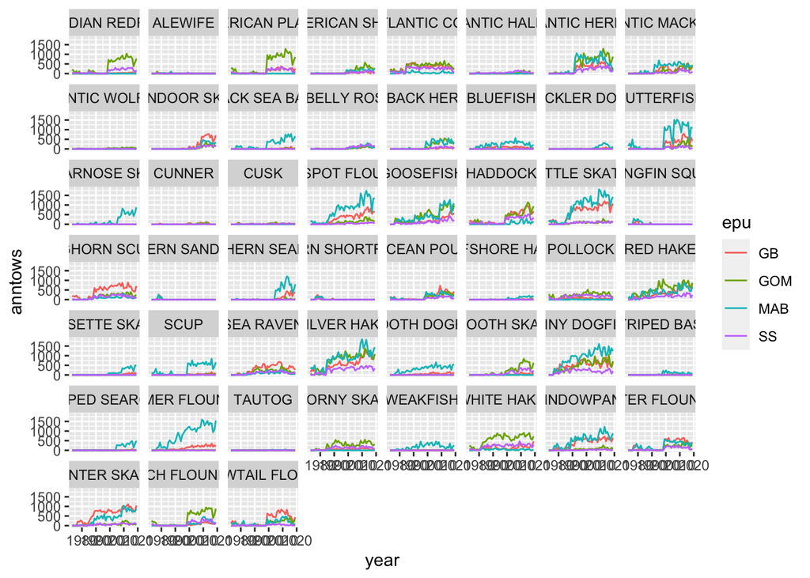

```r
# ggplot is a quick way to look across lots of things
# the aes statement sets up x and y axis variable
# with color differentiating area,
# line plot is defined with geom_line, and
# using facet_wrap does a plot for each predator (comname)

ntows %>% #starting with ntows, make these addtional changes
  ungroup() %>% #remove the groupings from the last step
  ggplot(aes(x=year, y=anntows, color=epu)) + #make a plot object
  geom_line() +
  facet_wrap(~comname)
```

### Filter down to a few predators

There are a lot of predators! So maybe we should just look at a few. To use a `filter` statement in our code to filter down to just a few species, we need to know the exact names of the species.

Here is code using the R function `unique` again to see all the species names in the dataset (the unique values in the comname column):

```r
unique(dietdat2$comname)
```

```
##  [1] "SMOOTH DOGFISH"          "SPINY DOGFISH"
##  [3] "BARNDOOR SKATE"          "WINTER SKATE"
##  [5] "CLEARNOSE SKATE"         "ROSETTE SKATE"
##  [7] "LITTLE SKATE"            "SMOOTH SKATE"
##  [9] "THORNY SKATE"            "ATLANTIC HERRING"
## [11] "ALEWIFE"                 "BLUEBACK HERRING"
## [13] "AMERICAN SHAD"           "OFFSHORE HAKE"
## [15] "SILVER HAKE"             "ATLANTIC COD"
## [17] "HADDOCK"                 "POLLOCK"
## [19] "WHITE HAKE"              "RED HAKE"
## [21] "CUSK"                    "ATLANTIC HALIBUT"
## [23] "AMERICAN PLAICE"         "SUMMER FLOUNDER"
## [25] "FOURSPOT FLOUNDER"       "YELLOWTAIL FLOUNDER"
## [27] "WINTER FLOUNDER"         "WITCH FLOUNDER"
## [29] "WINDOWPANE"              "BUCKLER DORY"
## [31] "ATLANTIC MACKEREL"       "BUTTERFISH"
## [33] "BLUEFISH"                "STRIPED BASS"
## [35] "BLACK SEA BASS"          "SCUP"
## [37] "WEAKFISH"                "ACADIAN REDFISH"
## [39] "BLACKBELLY ROSEFISH"     "LONGHORN SCULPIN"
## [41] "SEA RAVEN"               "NORTHERN SEAROBIN"
## [43] "STRIPED SEAROBIN"        "CUNNER"
## [45] "TAUTOG"                  "NORTHERN SAND LANCE"
## [47] "ATLANTIC WOLFFISH"       "OCEAN POUT"
## [49] "GOOSEFISH"               "NORTHERN SHORTFIN SQUID"
## [51] "LONGFIN SQUID"
```

Now we can choose a few and list them in the `filter` statement:

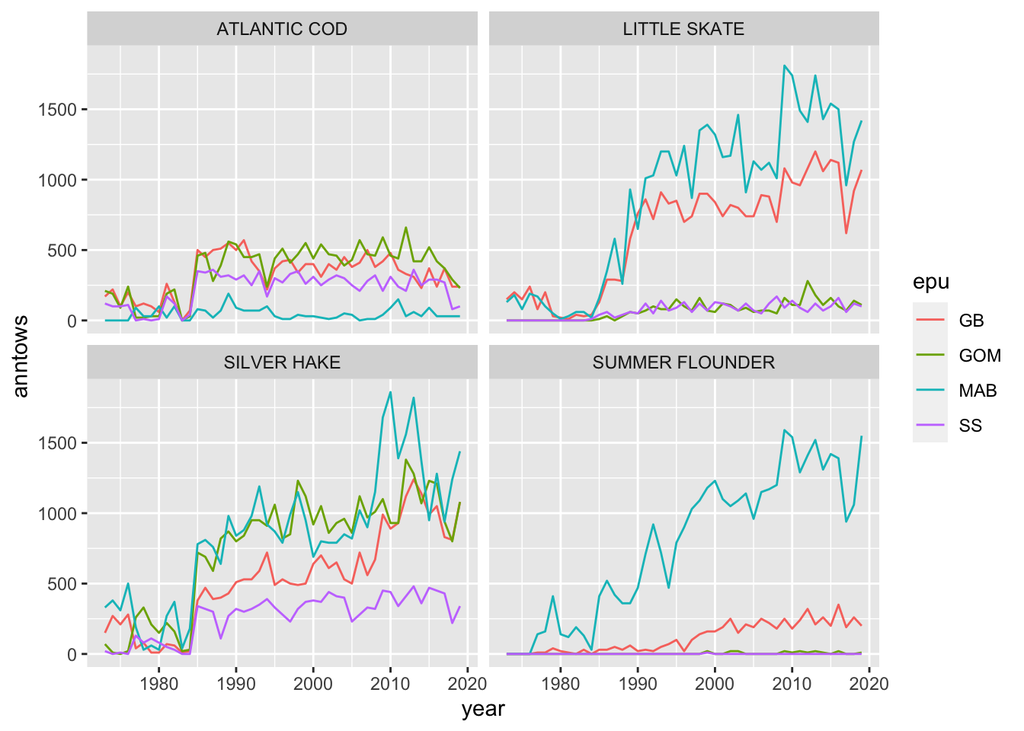

```r
# filter allows us to only look at a few species
# otherwise code is the same as above

ntows %>%
  ungroup() %>%
  filter(comname %in% c("SUMMER FLOUNDER",
                        "SILVER HAKE",
                        "LITTLE SKATE",
                        "ATLANTIC COD"
                        )) %>%
  ggplot(aes(x=year, y=anntows, color=epu)) +
  geom_line() +
  facet_wrap(~comname)
```

Now we have an idea of how many tows were sampled for diet in each area for each species over time.

### Summarize diet by predator and area

One question we may have is whether diet has changed over time for a particular predator. The number of tows sampled that we looked at above may affect our understanding.

Which of the columns should we look at for this, and how should we treat the data?

We may want to look at the proportion of each prey in the diet, but we can’t just sum up the `relmsw` column the way we did tows. This is a proportion relative to the `totwt` column, which is the total for epu, season, and year.

One way to look at the diet proportion data, then, is by epu, season, and year without trying to sum over seasons like we did in `ntows`. For example, we can pick a single predator and look at diet composition over time separately by epu and season:

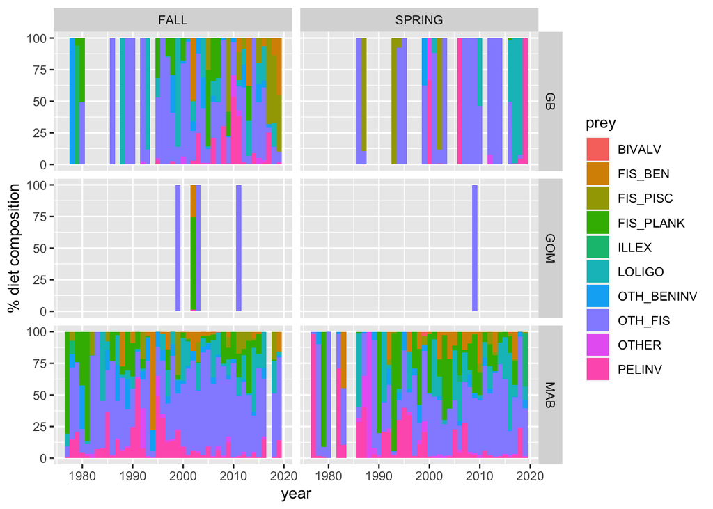

```r
dietdat2 %>%
  filter(comname %in% c("SUMMER FLOUNDER"),   #only look at this predator
         !is.na(relmsw)) %>%                  #take out the NA values (literally "not is NA")
  ggplot(aes(x=year, y=relmsw, fill=prey)) +  #year on x axis, %diet comp on y, by prey
  geom_bar(width = 1, stat = "identity") +    #stacked bar chart
  facet_grid(epu~season) +                    #separate by epu and season
  labs(y = "% diet composition")
```

The default colors aren’t that great at distinguishing the 10 prey categories. This is something we can change. One nice resource is [this website](http://medialab.github.io/iwanthue/) that allows you to select a range of colors for maximum contrast across a number of groups. So selecting 10 and colorblind friendly, we get a set of color codes to use in our plots. I’ve copied the Hex codes from the website.

After trying this, I decided to make the color for other fish (OTH_FIS) “gray” because the original blue looked too much like the one for benthic fish (FIS_BEN). I just commented out the hex code below. You can also just write in color names by consulting a list like [this one](http://derekogle.com/NCGraphing/resources/colors).

```r
preycol <- c(  #make object preycol by combining this list of hex codes
  "#3b6100",
  "#6481fc",
  "#6ce87e",
  "#c152c1",
  "#ddd87d",
  "#4a56cb",
  "#ed4c52",
  "grey", #"#0194d5",
  "#cd1d78",
  "#e289b3")
```

We can look at a different predator using the same code. We can also write a function that takes predator name as its argument and makes the plot; this way we don’t have to keep cutting and pasting.

```r
plotSpDiet <- function(dat, species){   #defines the name of the function and the requied inputs

dat %>%
  filter(comname %in% species,                #only look at this predator
         !is.na(relmsw)) %>%                  #take out the NA values (literally "not is NA")
  ggplot(aes(x=year, y=relmsw, fill=prey)) +  #year on x axis, %diet comp on y, by prey
  geom_bar(width = 1, stat = "identity") +    #stacked bar chart
  scale_fill_manual(values=preycol) +         #custom colors
  facet_grid(epu~season) +                    #separate by epu and season
  labs(y = "% diet composition",              #add sensible labels
       title = species)


}                                        #all function definitions end with the closed bracket
```

The function takes the name of the data object and the species common name (written exactly as it is in the file) to make the plot.

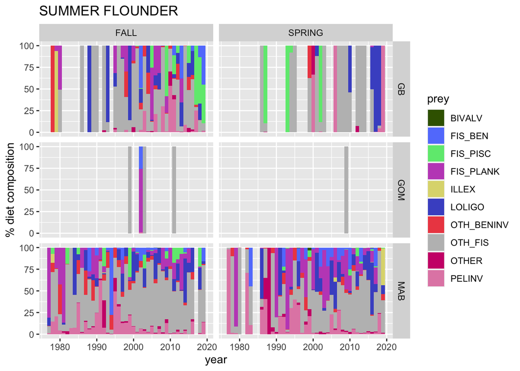

```r
plotSpDiet(dietdat2, "SUMMER FLOUNDER")
```

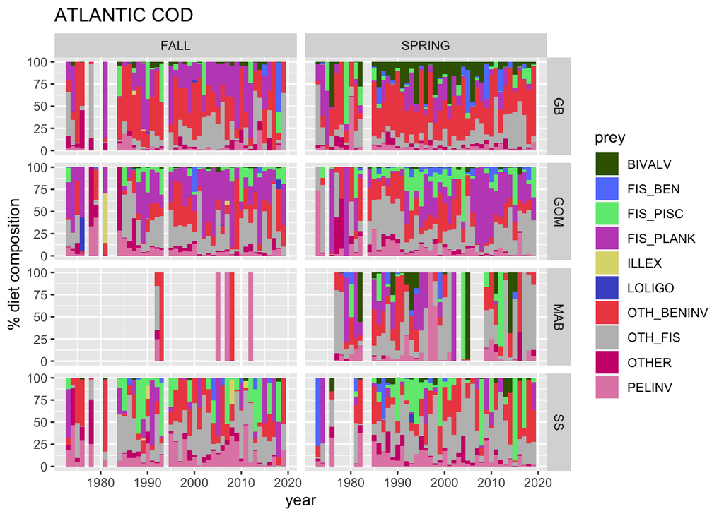

```r
plotSpDiet(dietdat2, "ATLANTIC COD")
```

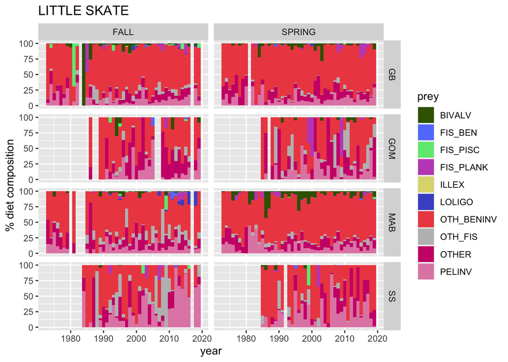

```r
plotSpDiet(dietdat2, "LITTLE SKATE")
```

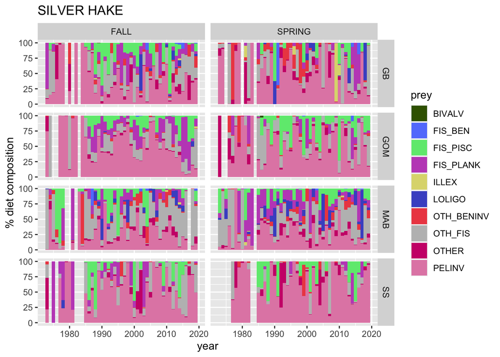

```r
plotSpDiet(dietdat2, "SILVER HAKE")
```

We can use the same function on the original dataset with fewer prey categories; maybe it is easier to see trends? Just call the same function with `dietdat1` as the input data. Since it has all the same column names, the same function works.

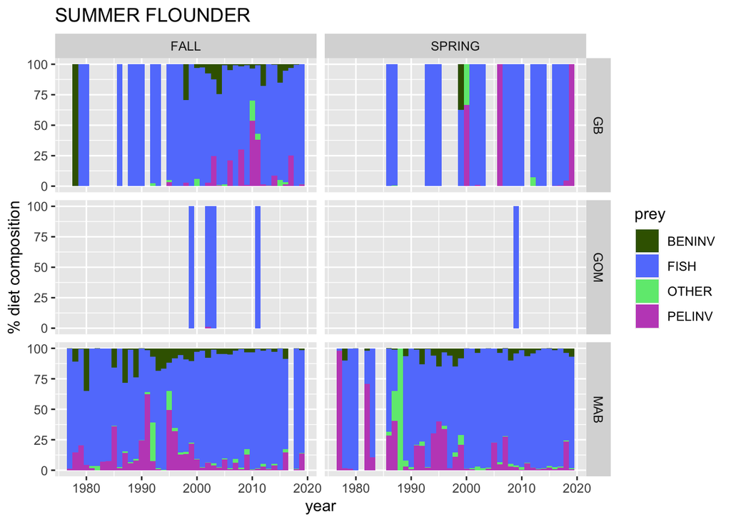

```r
plotSpDiet(dietdat1, "SUMMER FLOUNDER")
```

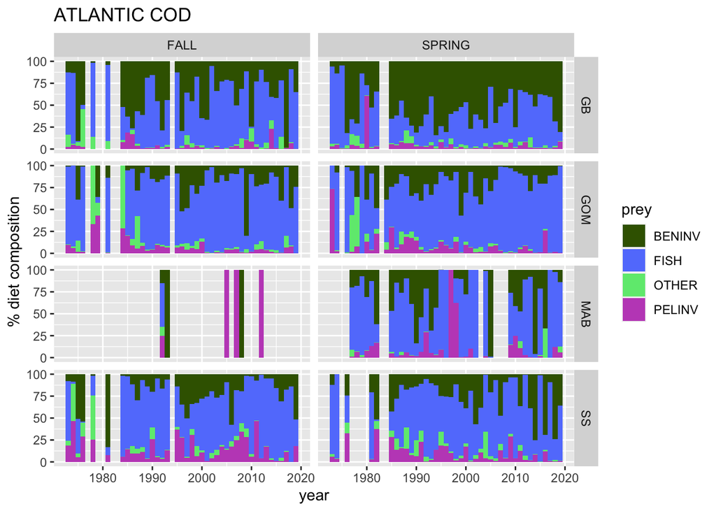

```r
plotSpDiet(dietdat1, "ATLANTIC COD")
```

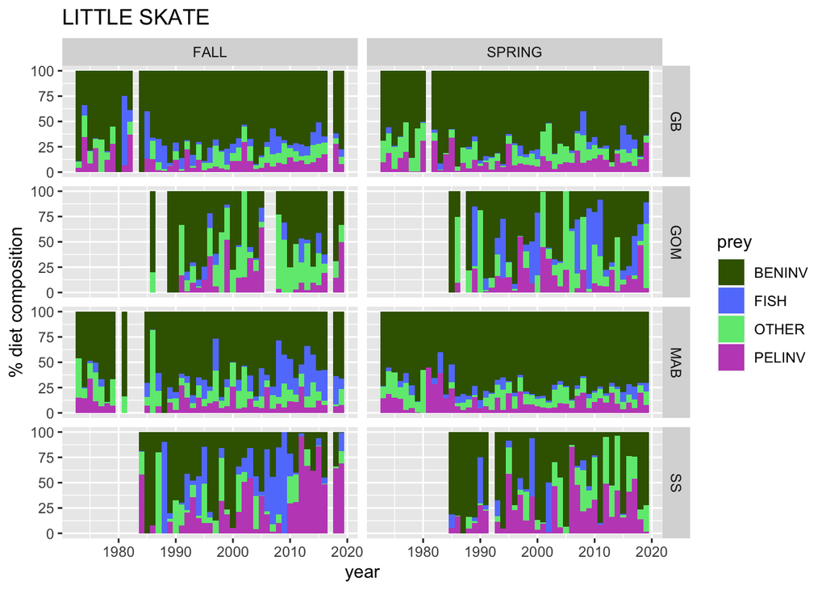

```r
plotSpDiet(dietdat1, "LITTLE SKATE")
```

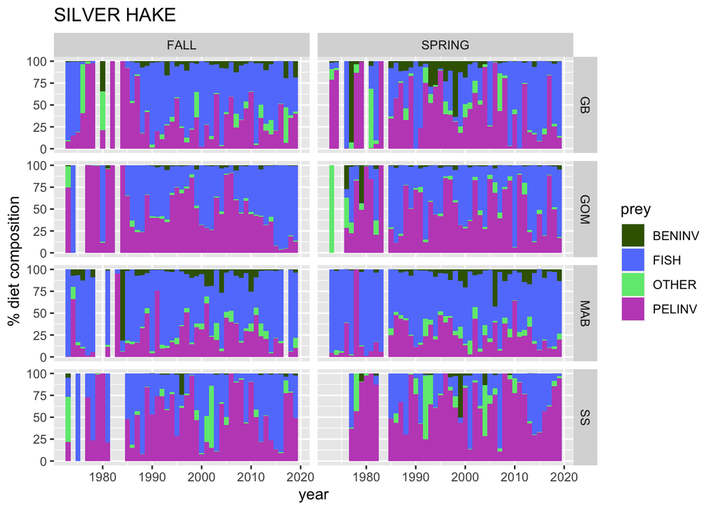

```r
plotSpDiet(dietdat1, "SILVER HAKE")
```

What if we wanted to see whether there are trends across all predators? I think we could multiply the diet proportion by the total stomach weight to convert to prey weight, then sum across some predator groups… but for this we should talk to Brian!